title: “WolfPackR: Analyzing Wolf Pack Territories”  
author: “Etienne Boncourt”  
date: “2026-03-27”  
output:  
rmarkdown::html_vignette:  
toc: true  
toc_float: true

# Introduction

The **WolfPackR** package provides a comprehensive toolkit for analyzing the genetic and spatial structures of wolf packs. This vignette demonstrates how to use **WolfPackR** to analyze wolf pack territories, from genetic relatedness to spatial pack visualization, using both simulated and real-world datasets.

# Data Preparation

First, we load the necessary libraries and datasets provided with the package.

```r
library(WolfPackR)
```

# Analysis Workflow

## 1. Simulated Dataset

### Genetic Groups

We start by identifying genetic groups using the `genetic_groups()` function. This function clusters individuals based on genetic relatedness.

```r
data("relate")
data("samples")

gengroups <- genetic_groups(relate, threshold = 0.4, estimator = "wang")
```

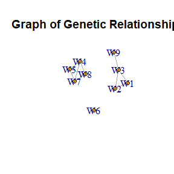

```r
obs <- merge(samples, gengroups, by = "Individual")
plot_packs(obs, group)
```

[interactive chart not shown]

### Ugly Ducklings

Next, we identify “ugly ducklings”—individuals that do not fit well into their assigned genetic groups—using the `ugly_ducklings()` function.

```r
ud_df <- ugly_ducklings(obs, group = group, min_overlap = 0.7, buffer = 0, mcp.percent = 100)
obs2 <- merge(samples, ud_df, by = "Individual")
plot_packs(obs2, new_group)
```

[interactive chart not shown]

### Spatial Groups

Finally, we refine the spatial grouping of individuals using the `spatial_groups()` function, which clusters individuals based on spatial proximity.

```r
spatgroups <- spatial_groups(obs2, group = "new_group", percentile = 100,
                             buffer_radius = 0.0000001, max_iterations = 20, min_mcp_overlap = 0.6)
obs3 <- merge(samples, spatgroups, by = "Individual")
plot_packs(obs3, Subgroup)
```

[interactive chart not shown]

## 2. Real-Life Dataset: Carpathian Wolves

### Genetic Groups

We apply the same workflow to a real-life dataset from Iosif et al. (2025), focusing on Carpathian wolves.

```r
data("Bruvo_Carpathians")
data("samples_Carpathians")

gengroups_carpat <- genetic_groups(Bruvo_Carpathians, threshold = 0.7, estimator = "1-Bruvo")
```

[figure not shown]

```r
obs_carpat <- merge(samples_Carpathians, gengroups_carpat, by = "Individual")
plot_packs(obs_carpat, group)
```

[interactive chart not shown]

### Ugly Ducklings

We identify “ugly ducklings” in the Carpathian dataset.

```r
ud_df_carpat <- ugly_ducklings(obs_carpat, group = group, min_overlap = 0.5, buffer = 0, mcp.percent = 100)
obs2_carpat <- merge(samples_Carpathians, ud_df_carpat, by = "Individual")
plot_packs(obs2_carpat, new_group)
```

[interactive chart not shown]

### Spatial Groups

We refine the spatial grouping for the Carpathian dataset.

```r
spatgroups_carpat <- spatial_groups(obs2_carpat, group = "new_group", percentile = 100,
                             buffer_radius = 0.0000001, max_iterations = 20, min_mcp_overlap = 0.5)
obs3_carpat <- merge(samples_Carpathians, spatgroups_carpat, by = "Individual")
plot_packs(obs3_carpat, Subgroup)
```

[interactive chart not shown]

# Conclusion

This vignette demonstrates the core functionality of **WolfPackR** for analyzing wolf pack territories using both simulated and real-world datasets. The package provides a robust framework for genetic and spatial analysis, enabling researchers to gain insights into wolf pack dynamics.

For more details, refer to the [WolfPackR GitHub repository](https://github.com/eboncourt/WolfPackR).